# Track Analysis Methods

# 3 Mean square displacement plots

A common analysis on migration data is generating mean square displacement (MSD) plots. For a range of time interval $\Delta t$, we compute the average squared displacement of all subtracks with that duration. Like with step-based approaches, we compute the metric on subtracks pooled from all individual cells – but now we also do this for subtracks of more than one step.

We can use the `subtracks()` function with varying `i` argument to obtain subtracks of different lengths, and then use `sapply()` to find a mean metric for each of these datasets. However, the package also contains a convenience function that does this automatically: `aggregate()`. For example, use this function to directly get the mean square displacement of all single steps:

```r
aggregate( TCells2, squareDisplacement, subtrack.length = 1 )
```

```
##   i    value
## 1 1 19.26447
```

where “i” is the subtrack length in number of steps, and “value” is the average value of the applied metric (in this case, square displacement) for all subtracks of that length in the data.

We can also report different summary statistics by changing the `FUN` argument (see `?aggregate.tracks`):

```r
aggregate( TCells2, squareDisplacement, subtrack.length = 1, FUN = "mean.se" )
```

```
##   i     mean    lower    upper
## 1 1 19.26447 17.65995 20.86899
```

This gives us not only the mean, but also the standard error.

Now, if we leave out the `subtrack.length`, `aggregate()` automatically computes the metric for subtracks of all possible lengths in the dataset and returns those in a dataframe:

```r
Tcell.msd <- aggregate( TCells2, squareDisplacement, FUN = "mean.se" )
str( Tcell.msd )
```

```
## 'data.frame':    39 obs. of  4 variables:
##  $ i    : num  1 2 3 4 5 6 7 8 9 10 ...
##  $ mean : num  19.3 41.5 67.9 97.1 128.3 ...
##  $ lower: num  17.7 39 64.4 92.4 122 ...
##  $ upper: num  20.9 43.9 71.3 101.9 134.5 ...
```

We can then use this for plotting:

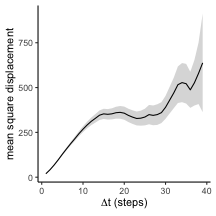

```r
ggplot( Tcell.msd, aes( x = i, y = mean ) ) +
  geom_ribbon( aes( ymin = lower, ymax = upper) , alpha = 0.2 ,color=NA ) +
  geom_line( ) +
  labs( x = expression( paste(Delta,"t (steps)") ),
        y = "mean square displacement") +
  theme_classic()
```

Plotting the standard error is useful because, as $\Delta t$ increases, the number of subtracks with that length decreases rapidly. MSD values at the high end of the plot therefore tend to be less reliable as they are based on very few observations.

Compare for example the number of subtracks of length 10 to the number of length 35:

```r
num10 <- length( subtracks( TCells2, 10 ) )
num35 <- length( subtracks( TCells2, 35 ) )
c( "10" = num10, "35" = num35 )
```

```
##  10  35
## 562  46
```

Now, let’s compare the MSD plot for the three different types of cells:

```r
# Combine into a single dataframe with one column indicating the celltype
# To truly compare them, report subtrack length not in number of steps but
# in their duration (which may differ between different datasets)
Tcell.msd$cells <- "T cells"
Tcell.msd$dt <- Tcell.msd$i * timeStep( TCells2 )
Bcell.msd <- aggregate( BCells2, squareDisplacement, FUN = "mean.se" )
Bcell.msd$cells <- "B cells"
Bcell.msd$dt <- Bcell.msd$i * timeStep( BCells2 )
Nphil.msd <- aggregate( Neutrophils2, squareDisplacement, FUN = "mean.se" )
Nphil.msd$cells <- "Neutrophils"
Nphil.msd$dt <- Nphil.msd$i * timeStep( Neutrophils2 )
msddata <- rbind( Tcell.msd, Bcell.msd, Nphil.msd )
head(msddata)
```

```
##   i      mean     lower     upper   cells  dt
## 1 1  19.26447  17.65995  20.86899 T cells  24
## 2 2  41.45140  38.97172  43.93109 T cells  48
## 3 3  67.85251  64.43261  71.27241 T cells  72
## 4 4  97.12745  92.37496 101.87993 T cells  96
## 5 5 128.25329 121.99665 134.50993 T cells 120
## 6 6 157.86364 149.92798 165.79929 T cells 144
```

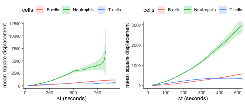

```r
# Plot
p1 <- ggplot( msddata, aes( x = dt , y = mean, color = cells, fill = cells ) ) +
  geom_ribbon( aes( ymin = lower, ymax = upper) , alpha = 0.2 ,color=NA ) +
  geom_line( ) +
  labs( x = expression( paste(Delta,"t (seconds)") ),
        y = "mean square displacement") +
  theme_classic() + theme(
    legend.position = "top"
  )
# Also make a zoomed version to look only at first part of the plot
pzoom <- p1 + coord_cartesian( xlim = c(0,500), ylim = c(0,3000) )
gridExtra::grid.arrange( p1, pzoom, ncol = 2 )
```

Note here that the bigger $\Delta t$, the less reliable the MSD becomes. This is especially the case when the imaging window is limited (as is often the case for two-photon experiments). The longer $\Delta t$, the more cells have the chance to leave the imaging window during that time, which means that there will be less data available to compute a mean on. Moreover, the data that is still there is biased: faster and more persistent cells will leave the imaging window more quickly, and are therefore underrepresented in the displacements measured at large $\Delta t$. This, for example, is one reason why the T-cell curve seems to flatten at larger $\Delta t$.

> Tip: `aggregate()` can also make MSD plots from non-overlapping subtracks or from subtracks starting at the first position of each track; see `?aggregate.tracks` for details.

# 4 Analyzing persistence

The downside of the MSD plot is that it is strongly affected by both speed *and* directionality of cells: faster cells displace more, as do cells that move straighter. It can therefore be worthwile to study cell speed and straightness or “persistence” independently.

### 4.1 Straightness metrics

The package implements several metrics that provide a measure of track straightness or directionality (see [Mohktari et al (2013)](https://www.ncbi.nlm.nih.gov/pubmed/24324630) for details): `displacementRatio()`, `outreachRatio`, `straightness()`, and `asphericity()`. These metrics can be applied to the data in the same way as was done for `speed()` in section 2 of this tutorial. See also `?TrackMeasures` for more information.

### 4.2 Autocorrelation plots

To analyze cell persistence, another good analysis is the autocorrelation plot: taking steps with $\Delta t$ time in between, how much do their directions of movement still correlate?

Officially, the autocorrelation plot is a plot of $\cos \alpha$ of two steps, $\vec{s_1}$ and $\vec{s_2}$, whose starting points are $\Delta t$ apart. This is equal to the dot product between $\vec{s_1}$ and $\vec{s_2}$ after normalizing both vectors to unit length. We can compute this again using `aggregate()` (see also the previous section):

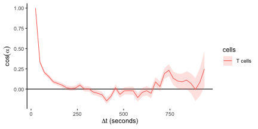

```r
Tcell.acor <- aggregate( TCells2, overallNormDot, FUN = "mean.se"  )
Tcell.acor$dt <- Tcell.acor$i * timeStep(TCells2)
Tcell.acor$cells <- "T cells"

ggplot( Tcell.acor, aes( x = dt , y = mean, color = cells, fill = cells ) ) +
  geom_hline( yintercept = 0 ) +
  geom_ribbon( aes( ymin = lower, ymax = upper) , alpha = 0.2 ,color=NA ) +
  geom_line( ) +
  labs( x = expression( paste(Delta,"t (seconds)") ),
        y = expression(cos(alpha))) +
  theme_classic() +
  theme( axis.line.x = element_blank() )
```

Note, however, that steps in which the cell barely moves can add a lot of noise to the analysis of angles. Since it makes no sense anyway to speak of persistent movement when a cell is not moving, we can avoid this by filtering for pairs of steps $\vec{s_1}$ and $\vec{s_2}$ that have at least some minimum displacement. To do this, we give `aggregate()` a function in the `filter.subtracks` argument:

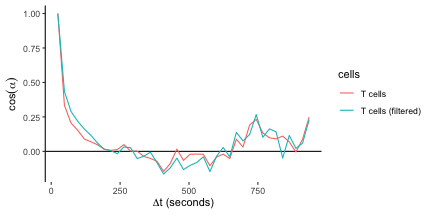

```r
# Returns TRUE if first and last step of a track are of the minimum length of 1 micron
check <- function(x){
  all( sapply( list(head(x,2),tail(x,2)), trackLength ) >= 1.0 )
}
# repeat analysis
Tcell.acor2 <- aggregate( TCells2, overallNormDot,
                     FUN = "mean.se", filter.subtracks = check )
Tcell.acor2$dt <- Tcell.acor2$i * timeStep(TCells2)
Tcell.acor2$cells <- "T cells (filtered)"

d <- rbind( Tcell.acor, Tcell.acor2 )

# compare
ggplot( d, aes( x = dt , y = mean, color = cells, fill = cells ) ) +
  geom_hline( yintercept = 0 ) +
  geom_line( ) +
  labs( x = expression( paste(Delta,"t (seconds)") ),
        y = expression(cos(alpha))) +
  theme_classic() +
  theme( axis.line.x = element_blank() )
```

The drop in autocorrelation is now slightly less steep, because the lack of correlation between steps where the cell does not move is not taken into account.

Another solution is to make the autocovariance plot instead of the autocorrelation plot, where we plot the dot product between the original unnormalized vectors $\vec{s_1} \bullet \vec{s_2}$ instead of normalizing them fist. The dot product is less sensitive to noise from very short steps and is therefore recommended:

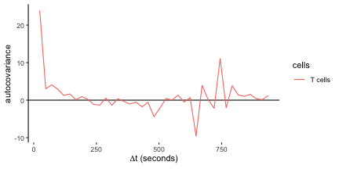

```r
# autocovariance
Tcell.acov <- aggregate( TCells2, overallDot,
                     FUN = "mean.se", filter.subtracks = check )
Tcell.acov$dt <- Tcell.acov$i * timeStep(TCells2)
Tcell.acov$cells <- "T cells"


# compare
ggplot( Tcell.acov, aes( x = dt , y = mean, color = cells, fill = cells ) ) +
  geom_hline( yintercept = 0 ) +
  geom_line( ) +
  labs( x = expression( paste(Delta,"t (seconds)") ),
        y = "autocovariance" ) +
  theme_classic() +
  theme( axis.line.x = element_blank() )
```

However, the autocovariance is no longer a number between 0 and 1, which is somewhat less convenient when comparing cell types moving at different speeds. We therefore divide all values by the maximum autocovariance at $\Delta t = 0$, and compare with the other celltypes:

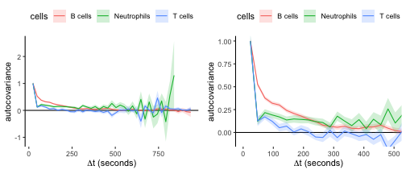

```r
# Normalized autocovariance
Tcell.acov[,2:4] <- Tcell.acov[,2:4] / Tcell.acov$mean[1]

# Other cells
Bcell.acov <- aggregate( BCells2, overallDot, FUN = "mean.se" )
Bcell.acov$cells <- "B cells"
Bcell.acov$dt <- Bcell.acov$i * timeStep( BCells2 )
Bcell.acov[,2:4] <- Bcell.acov[,2:4] / Bcell.acov$mean[1]

Nphil.acov <- aggregate( Neutrophils2, overallDot, FUN = "mean.se" )
Nphil.acov$cells <- "Neutrophils"
Nphil.acov$dt <- Nphil.acov$i * timeStep( Neutrophils2 )
Nphil.acov[,2:4] <- Nphil.acov[,2:4] / Nphil.acov$mean[1]

acovdata <- rbind( Tcell.acov, Bcell.acov, Nphil.acov )

# compare;
p1 <- ggplot( acovdata, aes( x = dt , y = mean, color = cells, fill = cells ) ) +
  geom_hline( yintercept = 0 ) +
  geom_ribbon( aes( ymin = lower, ymax = upper) , alpha = 0.2 ,color=NA ) +
  geom_line( ) +
  labs( x = expression( paste(Delta,"t (seconds)") ),
        y = "autocovariance" ) +
  theme_classic() +
  theme( axis.line.x = element_blank(),
         legend.position = "top" )

pzoom <- p1 + coord_cartesian( xlim = c(0,500), ylim  = c(-0.1,1) )
gridExtra::grid.arrange( p1, pzoom, ncol = 2 )
```

Note that neutrophils have a rapid initial drop in autocorrelation, but then maintain directional persistence over longer timescales; this is an indication of global directionality in the data (see below). T cells have a similar initial drop, but without the long-term directionality.

# 5 Analyzing directionality

Aside from directionality *within* a track segment (because of directional persistence), there can also be global directionality *between* different tracks: for example, when cells are moving in the direction of some target. The package supports several types of analyses to detect such directionality in a dataset.

### 5.1 Hotelling’s test

An unbiased method for detecting global directionality is Hotelling’s T-square test (see [Textor et al (2011)](https://www.ncbi.nlm.nih.gov/pubmed/21734152)), which tests if the mean step displacement vector is significantly different from the null vector. This method is powerful for detecting global movement biases when the direction is not known in advance.

For example, applying Hotelling’s test to the `Neutrophil` data:

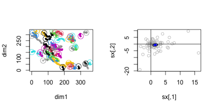

```
##
##  Hotelling's one sample T2-test
##
## data:
## T2 = 25.489, df1 = 2, df2 = 78, p-value = 1.836e-05
## alternative hypothesis: true location is not equal to c(0,0)
```

```r
par( mfrow=c(1,2) )
plot( Neutrophils2 )
hotellingsTest( Neutrophils2, plot = TRUE, col = "gray", step.spacing = 10 )
```

This shows there is a bias towards movement in the $(1,-1)$ direction. See the discussion of tissue drift in the vignette on quality control for a more extensive discussion on how to use Hotelling’s test to detect a global directional bias.

### 5.2 Angle analyses

#### 5.2.1 Overview: Angles and distances of steps to a fixed reference (point, plane, or direction)

The following functions support the computation of angles and distances of steps compared to a fixed reference:

- `angleToPoint( x, from = 1, p = c(1,1,1) )` : angle to the reference point with coordinates `p`.
- `angleToDir( x, from = 1, dvec = c(1,1,1) )` : angle to a reference direction specified by vector `dvec`.
- `angleToPlane( x, from = 1, p1, p2, p3 )` : angle to a plane specified by the points `p1`, `p2`, and `p3`.
- `distanceToPlane( x, from = 1, p1, p2, p3 )` : distance to a plane specified by the points `p1`, `p2`, and `p3`.
- `distanceToPoint( x, from = 1, p )` : distance to the reference point with coordinates `p`.

These functions take each track in tracks object `x`, extract the single steps starting at index `from` (by default, this is the first step in the track), and compute the angle of this step towards the reference. The distance functions compute the distance of the step starting point to the reference.

#### 5.2.2 Angles and distances to planes: detecting tracking artefacts

Angles and distances in reference to a plane are useful to detect tracking artefacts, see the vignette on quality control for a detailed example.

#### 5.2.3 Angle to a reference direction: powerful directionality tests when direction is known

While Hotelling’s test may be used to test for directionality in an unknown direction, we can increase the power of testing when the direction is known (for example, in an experiment with an artificial chemotactic gradient in a known direction).

As an example, let’s make an artificial dataset with additional movement in the direction $(1,1)$:

```r
# Directional movement is 0.05 micron/sec in each dimension
directional.speed <- c( 0.05, 0.05 )
add.dir <- function( x, speed.vector )
{
  # separate timepoints and coordinates
  tvec <- x[,1]
  coords <- x[,-1]

  # compute movement due to drift.
  speed.matrix <- matrix( rep( speed.vector, nrow(coords) ),
                          ncol = ncol(coords), byrow= TRUE )
  speed.matrix <- speed.matrix * tvec

  # Add drift to coordinates
  x[,-1] <- coords + speed.matrix
  return(x)
}

# Create data with directionality
TCells2.dir <- as.tracks( lapply( TCells2, add.dir, directional.speed ) )

# Plot both for comparison
# par(mfrow=c(1,2) )
# plot(TCells2, main = "original data" )
# plot(TCells2.dir, main = "with directional bias" )
```

Now, let’s view the distribution of step angles with the reference direction, and compare this to the original data:

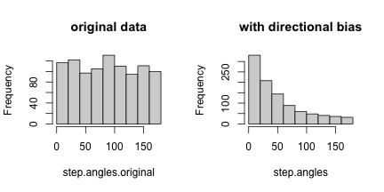

```r
step.angles <- sapply( subtracks( TCells2.dir, 1), angleToDir, dvec = c(1,1) )
step.angles.original <- sapply( subtracks( TCells2, 1 ), angleToDir, dvec = c(1,1) )
par(mfrow=c(1,2) )
hist( step.angles.original, main = "original data" )
hist( step.angles, main = "with directional bias" )
```

#### 5.2.4 Angles and distances to reference point: detecting movement towards a single point

Sometimes a directional bias is not in a fixed direction, but towards a fixed point. The direction of the bias then depends on the location a cell is in.

As an extreme example, let’s make an artificial dataset by normalizing all T cell tracks so that they end at the same endpoint:

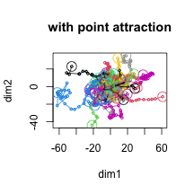

```r
# Normalize the endpoint by subtracting its coordinates from all other coordinates:
normalize.endpoint <- function( x ){
  coords <- x[,-1]
  coords.norm <- t( apply( coords, 1, function(a) a - coords[nrow(coords),] ) )
  x[,-1] <- coords.norm
  return(x)
}
TCells2.point <- as.tracks( lapply( TCells2, normalize.endpoint ) )

# Plot for comparison:
plot( TCells2.point, main = "with point attraction" )
```

Hotelling’s test cannot detect this bias, because the direction of the bias depends on where the track started:

```r
hotellingsTest( TCells2.point, step.spacing = 10, col = "gray" )
```

```
##
##  Hotelling's one sample T2-test
##
## data:
## T2 = 1.8532, df1 = 2, df2 = 109, p-value = 0.4023
## alternative hypothesis: true location is not equal to c(0,0)
```

Now, given that we know in which direction we expect the cells to move (towards point $(0,0)$), we can again use angle analysis to compute the step angles towards the central point:

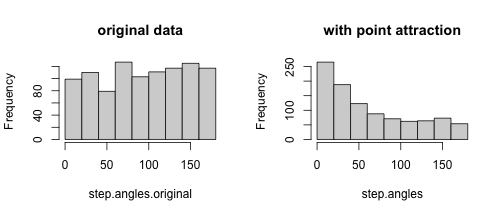

```r
step.angles <- sapply( subtracks( TCells2.point, 1), angleToPoint, p = c(0,0) )
step.angles.original <- sapply( subtracks( TCells2, 1 ), angleToPoint, p = c(0,0) )
par(mfrow=c(1,2) )
hist( step.angles.original, main = "original data" )
hist( step.angles, main = "with point attraction" )
```

Once again, there is an significant enrichment for small angles.

We can also plot the angle versus the distance to the point:

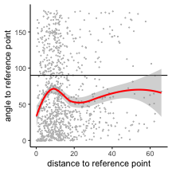

```r
step.distances <- sapply( subtracks( TCells2.point, 1), distanceToPoint, p = c(0,0) )

df <- data.frame( dist = step.distances,
                  angles = step.angles )
ggplot( df, aes( x = dist, y = angles ) ) +
  geom_point( size = 0.2, color = "gray") +
  geom_hline( yintercept = 90, color = "black" ) +
  stat_smooth( color = "red", method = "loess" ) +
  labs( x = "distance to reference point",
        y = "angle to reference point" ) +
  theme_classic()
```

In our artificial dataset, the average angle is below 90 degrees for any distance. But in case of true attraction towards a given point, we might expect the attraction to decrease as the distance to the point increases (for example, because cells at large distances do not feel the chemotactic gradient as much).

#### 5.2.5 Angles and distances between pairs of cells or individual steps

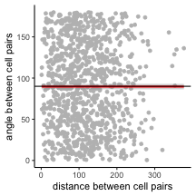

```r
df.cells <- analyzeCellPairs( TCells2 )

# Plot
ggplot( df.cells, aes( x = dist, y = angle ) ) +
  geom_point( color = "gray" ) +
  stat_smooth( span = 1, color = "red" )+
  labs( x = "distance between cell pairs",
        y = "angle between cell pairs" ) +
  geom_hline( yintercept = 90, color = "black" ) +
  theme_classic()
```

We expect angles between cell pairs to be on average 90 degrees. A lower average angle for cell pairs at low distances may indicate the formation of cell streams and collective migration. A systematic deviation from the 90 degree mean may indicate global directionality in the data.

We can do something similar on the level of single steps (where we take into account only pairs of steps that occur at the same time point, and we filter for steps that displace at least two micron):

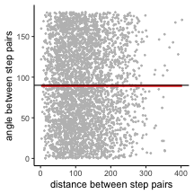

```r
df.steps <- analyzeStepPairs( TCells2, filter.steps = function(x) displacement(x)>2  )

# Plot
ggplot( df.steps, aes( x = dist, y = angle ) ) +
  geom_point( color = "gray", size = 0.5 ) +
  stat_smooth( color = "red" )+
  labs( x = "distance between step pairs",
        y = "angle between step pairs") +
  geom_hline( yintercept = 90, color = "black" ) +
  theme_classic()
```

Again, we expect to see an average angle of 90 degrees for all distances. See also the vignette on quality control.